# Data Visualization

Week 4

Published

October 10, 2025

# Before we start

- Any questions?

[Download script](https://artur-baranov.github.io/nu-ps403-ds/scripts/ps403-d_04.qmd)

[Download data](https://artur-baranov.github.io/nu-ps403-ds/data/whogov.csv)

**Review**

First, load the `tidyverse` library

```r
library(tidyverse)
```

Load the World Values Survey data from the previous week’s class.

```r
wvs = ...
```

Rename the variables:

- `B_COUNTRY_ALPHA` to `country`
- `Q191` to `violence`
- `Q194` to `political_violence`

```r
...
```

Calculate the average and standard deviation of `political_violence` by `country` using `group_by()` and `summarize()`. Save that to a new `pviolence_mean` object.

```r
pviolence_mean = wvs %>%
  ... %>%
  summarize(mean = ...,
            sd = ...)
```

Present first observations in the `pviolence_mean` using `head()`.

```r
head(pviolence_mean)
```

Leave only North American countries.

```r
north_america = c("CAN", "USA", "MEX")

pviolence_mean_filtered = ...
```

Load the `tinytable` library and present a table describing North American countries using `tt()`. Round the numbers up to two digits. Change the background color of Mexico’s (MEX) standard-deviation cell to yellow. And if you have underscores or some other special symbols (for example, the variable has `_` underscores), don’t forget to use `format_tt(escape = TRUE)`.

```r
library(tinytable)

pviolence_mean_filtered %>%
  tt() %>%
  format_tt(...) %>%
  ...(i = 2,
      ...,
      background = "yellow")
```

And a small preview of what’s going to come!

```r
ggplot(wvs) +
  geom_point(aes(x = violence,
                 y = political_violence))
```

Now, clear the environment using the broom icon!

# Agenda

- Summarizing Data
- Presenting Data with Graphs
- Exploring Relationships Visually

# Exploring Data

Today we are working with WhoGov dataset, which provides information on Members of Cabinets. As usual, I recommend taking a look at their [codebook](https://politicscentre.nuffield.ox.ac.uk/media/4117/whogov_codebook.pdf).

```r
whogov = read.csv("data/WhoGov.csv")
```

First of all, these are the following variables we are going to work with today:

- `country_name` is a country name
- `n_individuals` number of unique persons in the cabinet
- `leaderexperience_continuous` the number of years the person has been leader of the country in total.
- `system_category` the regime type
- `average_total` the average tenure for people in cabinet

Say, you are interested in the relationship between the leader’s duration in the office (`leaderexperience_continuous`) and the tenure for people in cabinet (`average_total`).

# One Continuous Variable

Start with exploring the distribution of average tenure of people in the cabinet (`average_total`)

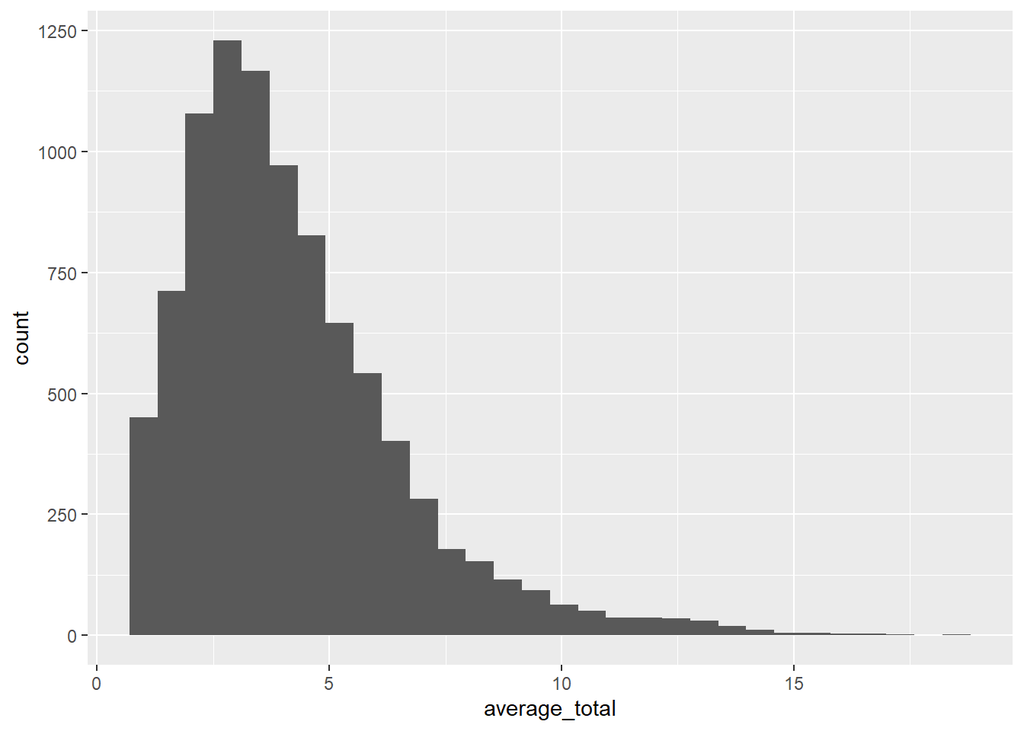

```r
ggplot(whogov) +
  geom_histogram(aes(x = average_total))
```

You can inform your reader by providing extra information. Add the average to the plot using `geom_vline()` and change the number of `bins` to 20. Save the graph to the `avgind_plot` object.

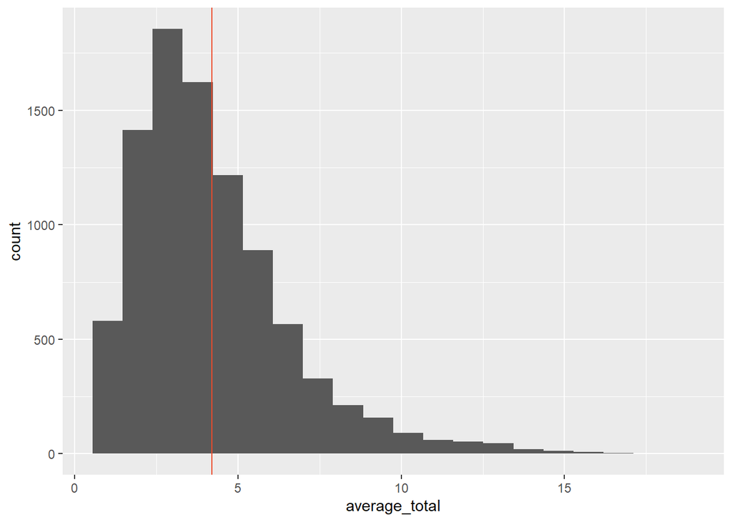

```r
avgind_plot = ggplot(whogov) +
  geom_histogram(aes(x = average_total), bins = 20) +
  geom_vline(aes(xintercept = mean(average_total, na.rm = TRUE)), color = "#EE4B2B")

avgind_plot
```

Let’s name the axes and customize the graph. Feel free to explore ggplot themes [here](https://r-charts.com/ggplot2/themes).

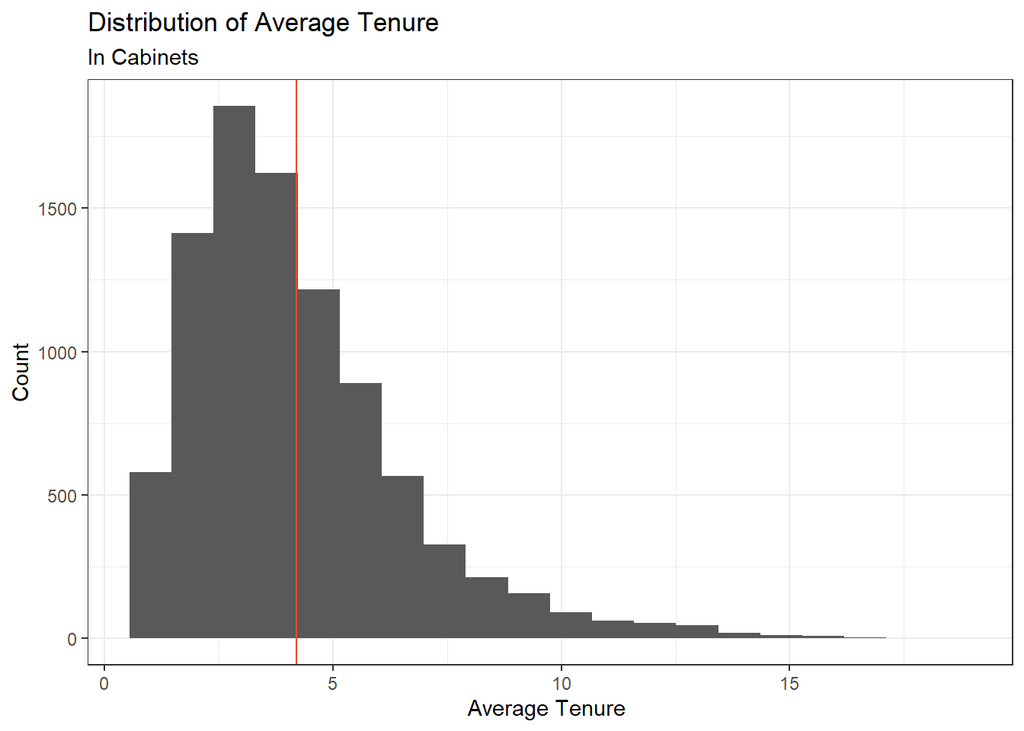

```r
avgind_plot = avgind_plot +
  labs(x = "Average Tenure ",
       y = "Count",
       title = "Distribution of Average Tenure",
       subtitle = "In Cabinets") +
  theme_bw()

avgind_plot
```

Change the breaks to a more readable format.

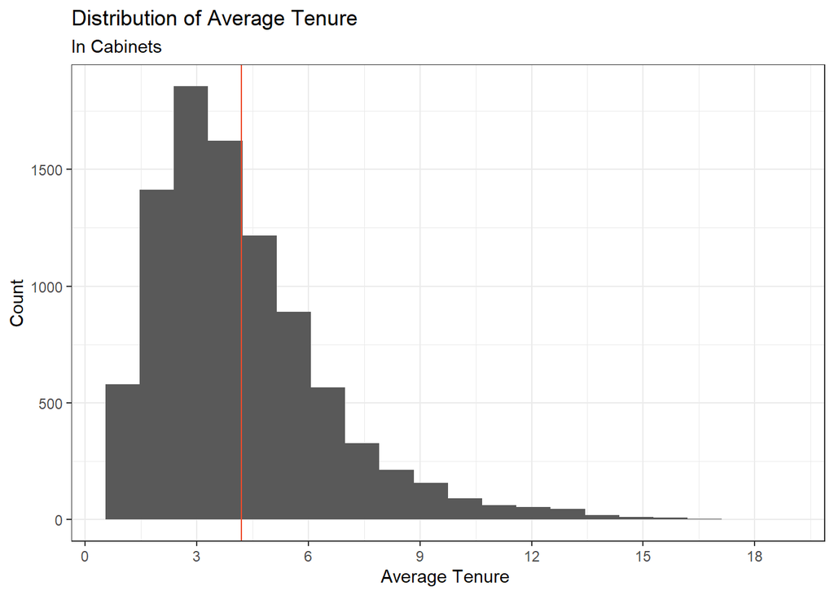

```r
avgind_plot +
  scale_x_continuous(breaks = seq(0,                         # start sequence from
                                  max(whogov$average_total,
                                      na.rm = TRUE),         # end sequence with
                                  3))                        # increment
```

# Two Continuous Variables

Now, continue exploring the relationship we were interested in. Let’s plot two distributions with densities. Make sure to go through the syntax. And be careful, now the X axis named incorrectly!

- Compare the distributions
- What alternative plot would be more suitable for comparing distributions?

Add `xlim(-5, 20)`

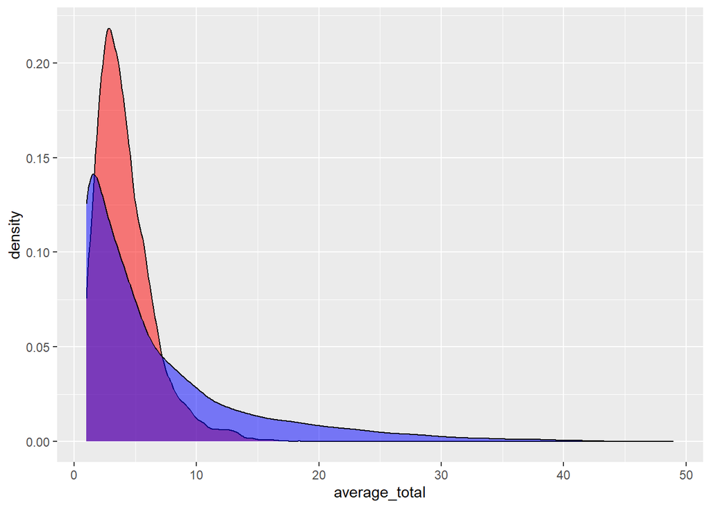

```r
ggplot(whogov) +
  geom_density(aes(x = average_total), fill = "red", alpha = 0.5) +
  geom_density(aes(x = leaderexperience_continuous), fill = "blue", alpha = 0.5)
```

Let’s draw a scatter plot using `geom_point()`. It’s more appropriate if we are interested in a relationship, rather than distribution comparison. What’s going on?

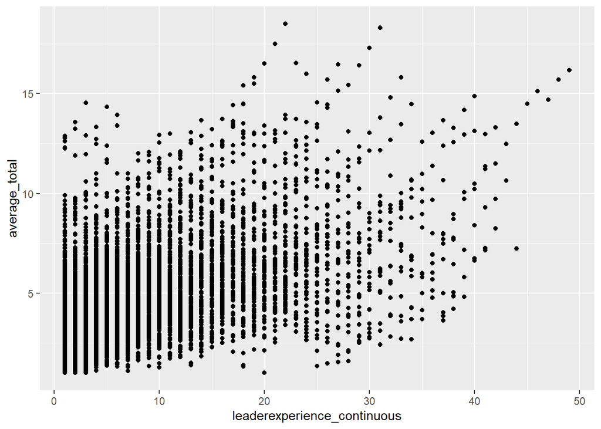

```r
ggplot(whogov) +
  geom_point(aes(x = leaderexperience_continuous,
                 y = average_total))
```

Let’s zoom in to explore two political regimes. Use `system_category` to leave only `Military dictatorship` and `Parliamentary democracy`.

```r
two_regimes = whogov %>%
  filter(system_category %in% c("Military dictatorship",
                                                "Parliamentary democracy"))
```

Then, color the points.

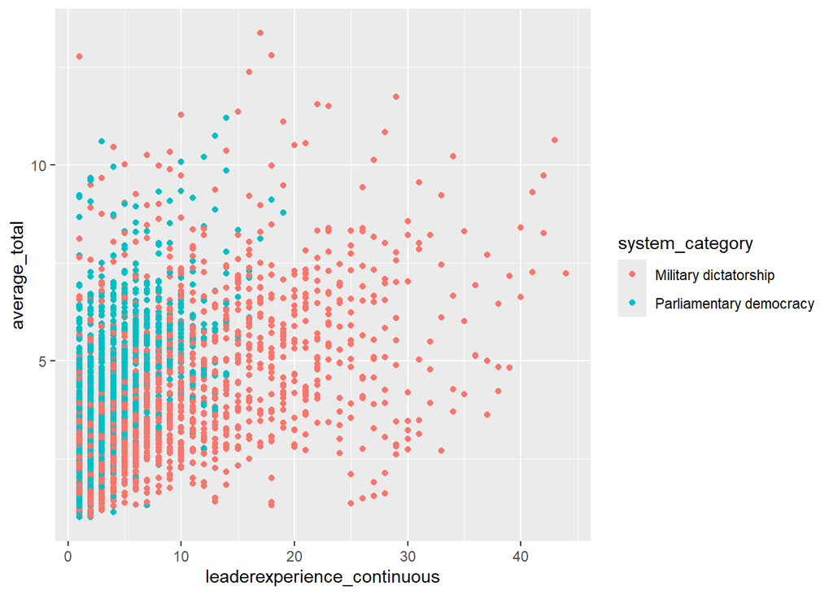

```r
regime_tenure = ggplot(two_regimes) +
                geom_point(aes(x = leaderexperience_continuous,
                               y = average_total,
                               color = system_category))

regime_tenure
```

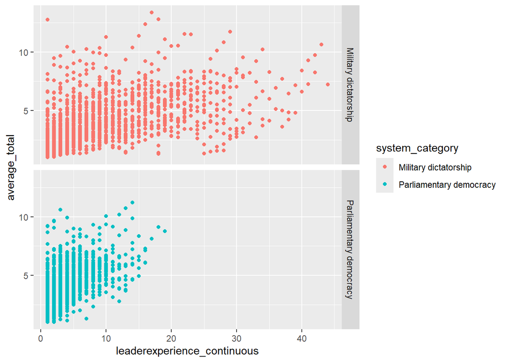

```r
regime_tenure = regime_tenure +
  facet_grid(system_category ~ .)

regime_tenure
```

Add title, name the axes and add a `theme_minimal()`.

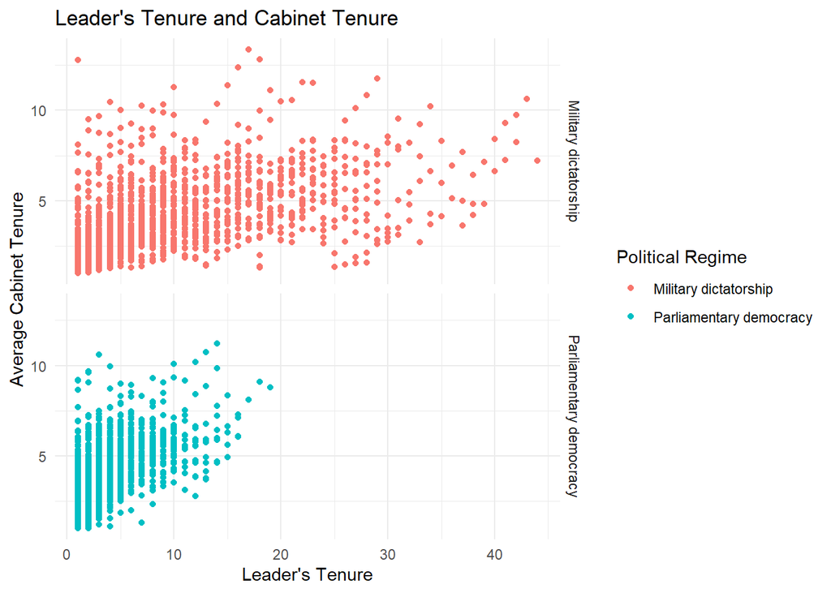

```r
regime_tenure +
  labs(y = "Average Cabinet Tenure",
       x = "Leader's Tenure",
       title = "Leader's Tenure and Cabinet Tenure",
       color = "Political Regime") +
  theme_minimal()
```

```r
cor(two_regimes$n_individuals, two_regimes$leaderexperience_continuous)
```

```
[1] 0.2308111
```

For your reference, take a look on the [cheatsheet](https://rstudio.github.io/cheatsheets/html/data-visualization.html).

# Check list

- I have no trouble naming my axes and providing titles to the plot with `labs()` function.
- I know that I can draw distributions with `geom_density()`.
- I know I can work with `scale_x_...` and `scale_y_...` to change the presentation of X or Y axes.
- I can create separate plots for different groups using `facet_grid()` (and with `facet_wrap()` – take a look on the exercises).
- I like customizing graphs with different themes! And I know how to change colors of elements in `ggplot()`.

# Extra

## Plotting a categorical variable

You can use histograms to count number of observations in each category, and then plot this count. Let’s try this out with political regimes (`system_category`). First, count the number of observations in each group. This is a dataframe.

```r
regime_count = whogov %>%
  group_by(system_category) %>%
  count()

regime_count
```

```
# A tibble: 9 × 2
# Groups:   system_category [9]
  system_category               n
  <chr>                     <int>
1 Civilian dictatorship      2630
2 Crown Colony                  2
3 French Overseas Territory    10
4 Military dictatorship      1680
5 Mixed democratic           1125
6 Parliamentary democracy    1647
7 Part of Yugoslavia            9
8 Presidential democracy     1406
9 Royal dictatorship          644
```

Now, plot it using `geom_col()`.

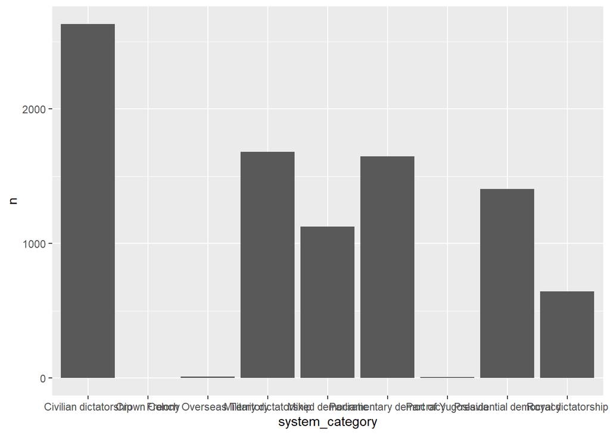

```r
regime_count %>%
  ggplot(aes(x = system_category,
             y = n)) +
  geom_col()
```

Change the order using `reorder()`, so the the count is presented consecutively.

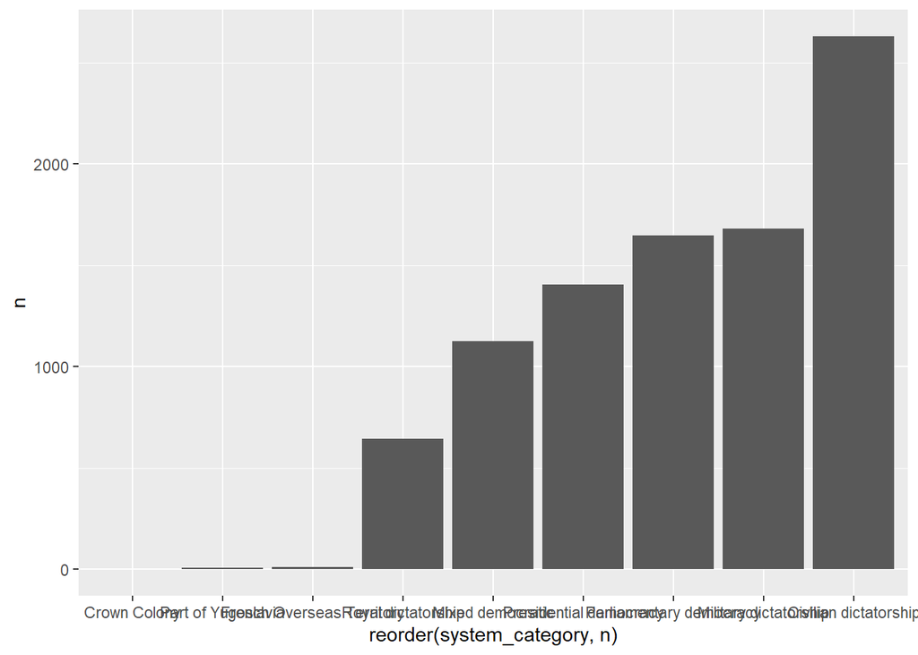

```r
regime_count %>%
  ggplot(aes(x = reorder(system_category, n),
             y = n)) +
  geom_col()
```

Now, customize the graph. Change the color of the bars with `fill =` argument in `geom_col()`, flip the axes making it easier to read names of the regime with `coord_flip()`. Add names of the axes with `labs()`, and change the theme to `theme_dark`.

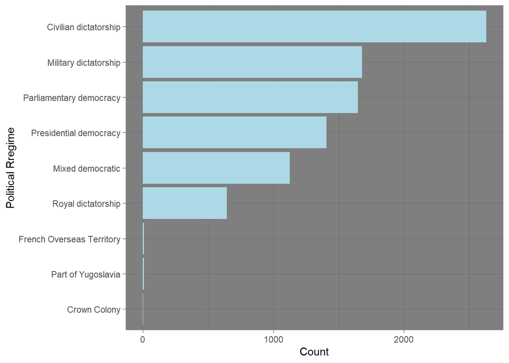

```r
regime_count %>%
  ggplot(aes(x = reorder(system_category, n),
             y = n)) +
  geom_col(fill = "lightblue") +
  coord_flip() +
  labs(x = "Political Rregime",
       y = "Count") +
  theme_dark()
```